# Tidy text and sentiment analysis

## Removing `$` and `,` in Practice

`readr::parse_*` is a number of useful helper functions for parsing columns

```r
head(readr::parse_number(raw_salary_data$AnnualSalary))
```

```
[1] 11310 53428 68300 62000 43999 52000
```

```r
raw_salary_data %>%
  mutate(across(matches("Salary|Pay"), readr::parse_number)) %>%
  select(matches("Salary|Pay"))
```

```
# A tibble: 18,981 × 2
   AnnualSalary GrossPay
          <dbl>    <dbl>
 1        11310     874.
 2        53428   52868.
 3        68300   67439.
 4        62000   58655.
 5        43999   39687.
 6        52000   47020.
 7        62175   61452.
 8        70918   87900.
 9        42438   53668.
10        11310      NA
# ℹ 18,971 more rows
```

## Tidying Text - What about all of Jane Austen’s Novels?

## Jane Austen

[figure not shown]

## Data Available via: `janeaustenr`

Attached with row numbers (by book).

```r
library(janeaustenr)
original_books = austen_books() %>%
  group_by(book) %>%
  mutate(linenumber = row_number()) %>%
  ungroup()
head(original_books)
```

```
# A tibble: 6 × 3
  text                    book                linenumber
  <chr>                   <fct>                    <int>
1 "SENSE AND SENSIBILITY" Sense & Sensibility          1
2 ""                      Sense & Sensibility          2
3 "by Jane Austen"        Sense & Sensibility          3
4 ""                      Sense & Sensibility          4
5 "(1811)"                Sense & Sensibility          5
6 ""                      Sense & Sensibility          6
```

## TidyText

[figure not shown]

http://joss.theoj.org/papers/89fd1099620268fe0342ffdcdf66776f

## A nice tutorial

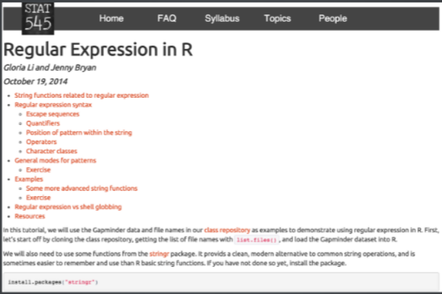

http://stat545-ubc.github.io/block022_regular-expression.html

## Large workhorse function: `unnest_tokens`

```r
library(tidytext)
txt = c("These are words", "so are these", "this is running on")
sentence = c(1, 2, 3)
dat = tibble(txt, sentence)
unnest_tokens(dat, tok, txt)
```

```
# A tibble: 10 × 2
   sentence tok
      <dbl> <chr>
 1        1 these
 2        1 are
 3        1 words
 4        2 so
 5        2 are
 6        2 these
 7        3 this
 8        3 is
 9        3 running
10        3 on
```

## What is tokenization?

> “The process of segmenting running text into words and sentences.”
- Split on white space/punctuation
- Make lower case
- Keep contractions together
- Maybe put quoted words together (not in unnest_tokens)

## One token per row

```r
tidy_books = original_books %>% unnest_tokens(word, text)
head(tidy_books)
```

```
# A tibble: 6 × 3
  book                linenumber word
  <fct>                    <int> <chr>
1 Sense & Sensibility          1 sense
2 Sense & Sensibility          1 and
3 Sense & Sensibility          1 sensibility
4 Sense & Sensibility          3 by
5 Sense & Sensibility          3 jane
6 Sense & Sensibility          3 austen
```

## Stop words/words to filter

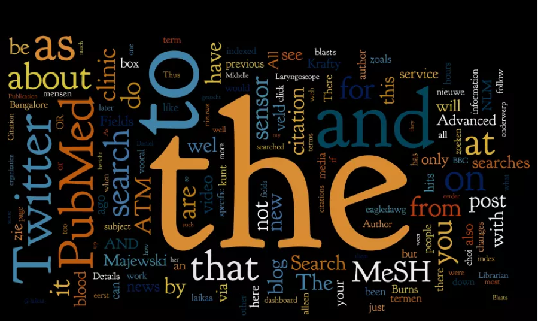

http://xpo6.com/list-of-english-stop-words/

## Stop words/words to filter

```r
tidy_books %>%
  group_by(word) %>%
  tally() %>%
  arrange(desc(n))
```

```
# A tibble: 14,520 × 2
   word      n
   <chr> <int>
 1 the   26351
 2 to    24044
 3 and   22515
 4 of    21178
 5 a     13408
 6 her   13055
 7 i     12006
 8 in    11217
 9 was   11204
10 it    10234
# ℹ 14,510 more rows
```

## Top Words by Book

```r
tidy_books %>%
  count(book, word) %>%
  arrange(desc(n)) %>%
  group_by(book) %>%
  slice(1L)
```

```
# A tibble: 6 × 3
# Groups:   book [6]
  book                word      n
  <fct>               <chr> <int>
1 Sense & Sensibility to     4116
2 Pride & Prejudice   the    4331
3 Mansfield Park      the    6206
4 Emma                to     5239
5 Northanger Abbey    the    3179
6 Persuasion          the    3329
```

## Filtering with joins

```r
head(stop_words)
```

```
# A tibble: 6 × 2
  word      lexicon
  <chr>     <chr>
1 a         SMART
2 a's       SMART
3 able      SMART
4 about     SMART
5 above     SMART
6 according SMART
```

```r
tidy_books = tidy_books %>% anti_join(stop_words, by = "word")
head(tidy_books)
```

```
# A tibble: 6 × 3
  book                linenumber word
  <fct>                    <int> <chr>
1 Sense & Sensibility          1 sense
2 Sense & Sensibility          1 sensibility
3 Sense & Sensibility          3 jane
4 Sense & Sensibility          3 austen
5 Sense & Sensibility          5 1811
6 Sense & Sensibility         10 chapter
```

## Top Words after joining

```r
tidy_books %>%
  count(word) %>%
  arrange(desc(n))
```

```
# A tibble: 13,914 × 2
   word       n
   <chr>  <int>
 1 miss    1855
 2 time    1337
 3 fanny    862
 4 dear     822
 5 lady     817
 6 sir      806
 7 day      797
 8 emma     787
 9 sister   727
10 house    699
# ℹ 13,904 more rows
```

## Top Words by Book after joining

```r
top_book_words = tidy_books %>%
  count(word, book) %>%
  arrange(desc(n)) %>%
  group_by(book)
(top_book_words %>% slice(1:2))
```

```
# A tibble: 12 × 3
# Groups:   book [6]
   word      book                    n
   <chr>     <fct>               <int>
 1 elinor    Sense & Sensibility   623
 2 marianne  Sense & Sensibility   492
 3 elizabeth Pride & Prejudice     597
 4 darcy     Pride & Prejudice     373
 5 fanny     Mansfield Park        816
 6 crawford  Mansfield Park        493
 7 emma      Emma                  786
 8 miss      Emma                  599
 9 catherine Northanger Abbey      428
10 miss      Northanger Abbey      206
11 anne      Persuasion            447
12 captain   Persuasion            303
```

## Sentiment analysis

“I hate this stupid class. But I love the work”

## Sentiment analysis

“I hate this stupid class. But I love the work”

## Sentiment analysis

“I hate this stupid class. But I love the work”  
“Oh yeah, I totally love doing coding sessions”

## Sentiments

```r
bing = tidytext::sentiments
head(bing)
```

```
# A tibble: 6 × 2
  word       sentiment
  <chr>      <chr>
1 2-faces    negative
2 abnormal   negative
3 abolish    negative
4 abominable negative
5 abominably negative
6 abominate  negative
```

```r
(dupes = bing %>% janitor::get_dupes(word))
```

```
# A tibble: 6 × 3
  word        dupe_count sentiment
  <chr>            <int> <chr>
1 envious              2 positive
2 envious              2 negative
3 enviously            2 positive
4 enviously            2 negative
5 enviousness          2 positive
6 enviousness          2 negative
```

## Sentiments: A little Tidying

Let’s remove those cases that it says these duplicates were positive

```r
bing = bing %>% # remove positive envy!
  anti_join(dupes %>% filter(sentiment == "positive"))
```

```
Joining with `by = join_by(word, sentiment)`
```

```r
anyDuplicated(bing$word) == 0
```

```
[1] TRUE
```

## Aside: `any(duplicated(x))` vs. `anyDuplicated(x) == 0` speed

Functions useful for checking and speed (big data): `anyNA` and `anyDuplicated

```r
microbenchmark::microbenchmark(
  anyDup = anyDuplicated(bing$word) == 0,
  any_dup = any(duplicated(bing$word)),
  anyNA = anyNA(bing$word),
  any_is_na = any(is.na(bing$word))
)
```

```
Unit: microseconds
      expr     min       lq      mean   median       uq     max neval  cld
    anyDup 113.874 120.2800 123.38984 122.2095 123.1165 197.919   100 a
   any_dup 125.706 132.9115 135.12509 133.8015 134.8670 184.376   100  b
     anyNA   4.733   4.9855   5.39127   5.5085   5.7420   7.244   100   c
 any_is_na  20.830  21.2065  22.05943  21.5520  21.9970  40.490   100    d
```

## Top Word Sentiments

Miss - may be misclassified (e.g. “Miss Elizabeth”)

```r
top_book_words %>% slice(1:2) %>% left_join(bing, by = join_by(word))
```

```
# A tibble: 12 × 4
# Groups:   book [6]
   word      book                    n sentiment
   <chr>     <fct>               <int> <chr>
 1 elinor    Sense & Sensibility   623 <NA>
 2 marianne  Sense & Sensibility   492 <NA>
 3 elizabeth Pride & Prejudice     597 <NA>
 4 darcy     Pride & Prejudice     373 <NA>
 5 fanny     Mansfield Park        816 <NA>
 6 crawford  Mansfield Park        493 <NA>
 7 emma      Emma                  786 <NA>
 8 miss      Emma                  599 negative
 9 catherine Northanger Abbey      428 <NA>
10 miss      Northanger Abbey      206 negative
11 anne      Persuasion            447 <NA>
12 captain   Persuasion            303 <NA>
```

## Top Word Sentiments

```r
top_book_words %>% inner_join(bing, by = join_by(word)) %>% slice(1:2)
```

```
# A tibble: 12 × 4
# Groups:   book [6]
   word     book                    n sentiment
   <chr>    <fct>               <int> <chr>
 1 miss     Sense & Sensibility   210 negative
 2 happy    Sense & Sensibility   100 positive
 3 miss     Pride & Prejudice     283 negative
 4 love     Pride & Prejudice      92 positive
 5 miss     Mansfield Park        432 negative
 6 love     Mansfield Park        124 positive
 7 miss     Emma                  599 negative
 8 poor     Emma                  136 negative
 9 miss     Northanger Abbey      206 negative
10 pleasure Northanger Abbey       48 positive
11 miss     Persuasion            125 negative
12 happy    Persuasion             64 positive
```

## Assigning sentiments to words

```r
janeaustensentiment = tidy_books %>%
  inner_join(bing, by = join_by(word)) %>%
  count(book, page = linenumber %/% 80, sentiment) %>%
  spread(sentiment, n, fill = 0) %>%
  mutate(sentiment = positive - negative)
head(janeaustensentiment)
```

```
# A tibble: 6 × 5
  book                 page negative positive sentiment
  <fct>               <dbl>    <dbl>    <dbl>     <dbl>
1 Sense & Sensibility     0       16       26        10
2 Sense & Sensibility     1       19       44        25
3 Sense & Sensibility     2       12       23        11
4 Sense & Sensibility     3       15       22         7
5 Sense & Sensibility     4       16       29        13
6 Sense & Sensibility     5       16       39        23
```

## Assigning sentiments to words

```r
janeaustensentiment %>%
  group_by(book) %>%
  slice(1:3)
```

```
# A tibble: 18 × 5
# Groups:   book [6]
   book                 page negative positive sentiment
   <fct>               <dbl>    <dbl>    <dbl>     <dbl>
 1 Sense & Sensibility     0       16       26        10
 2 Sense & Sensibility     1       19       44        25
 3 Sense & Sensibility     2       12       23        11
 4 Pride & Prejudice       0        7       15         8
 5 Pride & Prejudice       1       20       14        -6
 6 Pride & Prejudice       2       15       14        -1
 7 Mansfield Park          0       29       29         0
 8 Mansfield Park          1       20       30        10
 9 Mansfield Park          2       27       23        -4
10 Emma                    0       31       35         4
11 Emma                    1       28       23        -5
12 Emma                    2       30       20       -10
13 Northanger Abbey        0       27       21        -6
14 Northanger Abbey        1       22       32        10
15 Northanger Abbey        2       25       34         9
16 Persuasion              0       20       28         8
17 Persuasion              1       21       28         7
18 Persuasion              2       24       22        -2
```

## Assigning sentiments to words: removing “miss”

```r
janeaustensentiment_nomiss = tidy_books %>%
  filter(word != "miss") %>%
  inner_join(bing, by = join_by(word)) %>%
  count(book, page = linenumber %/% 80, sentiment) %>%
  spread(sentiment, n, fill = 0) %>%
  mutate(sentiment = positive - negative)
```

## Plotting the sentiment trajectory (ggplot2 loaded)

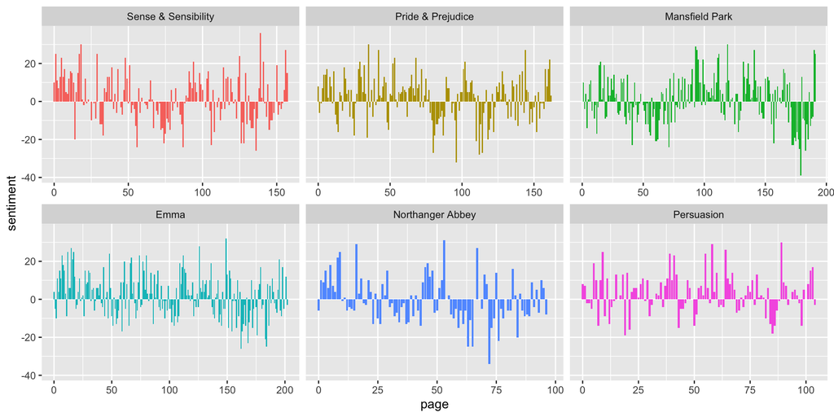

```r
ggplot(janeaustensentiment, aes(page, sentiment, fill = book)) +
  geom_bar(stat = "identity", show.legend = FALSE) +
  facet_wrap(~book, ncol = 3, scales = "free_x")
```

## Plotting the cumulative sentiment

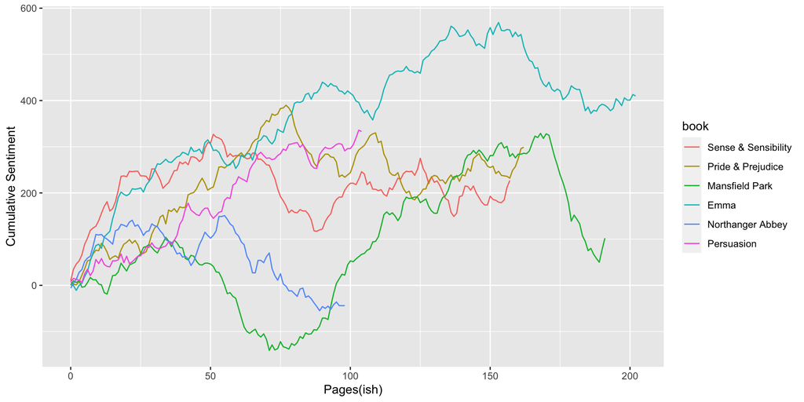

```r
janeaustensentiment %>%
  group_by(book) %>%
  mutate(sentiment = cumsum(sentiment)) %>%
  ggplot(aes(page, sentiment, colour = book)) +
  geom_line() + ylab("Cumulative Sentiment") + xlab("Pages(ish)")
```

## Plotting the cumulative sentiment (normalized book length)

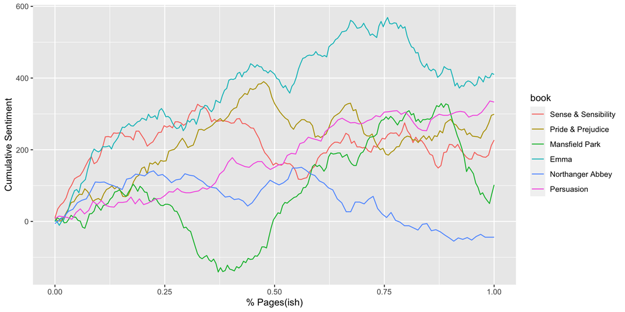

```r
janeaustensentiment %>%
  group_by(book) %>%
  mutate(sentiment = cumsum(sentiment),
         page = page/max(page)) %>%
  ggplot(aes(page, sentiment, colour = book)) +
  geom_line() + ylab("Cumulative Sentiment") + xlab("% Pages(ish)")
```

## Plotting the cumulative sentiment (normalized book length)

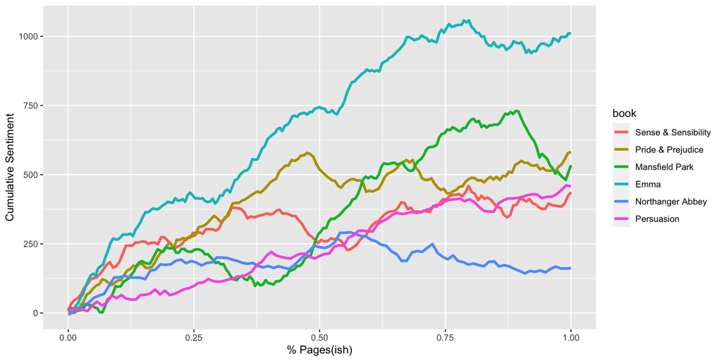

```r
(p = janeaustensentiment_nomiss %>%
  group_by(book) %>%
  mutate(sentiment = cumsum(sentiment),
         page = page/max(page)) %>%
  ggplot(aes(page, sentiment, colour = book)) +
  geom_line(linewidth = 1.25) + ylab("Cumulative Sentiment") + xlab("% Pages(ish)"))
```

## Plotting Aside: Put Legend **Inside** the Figure

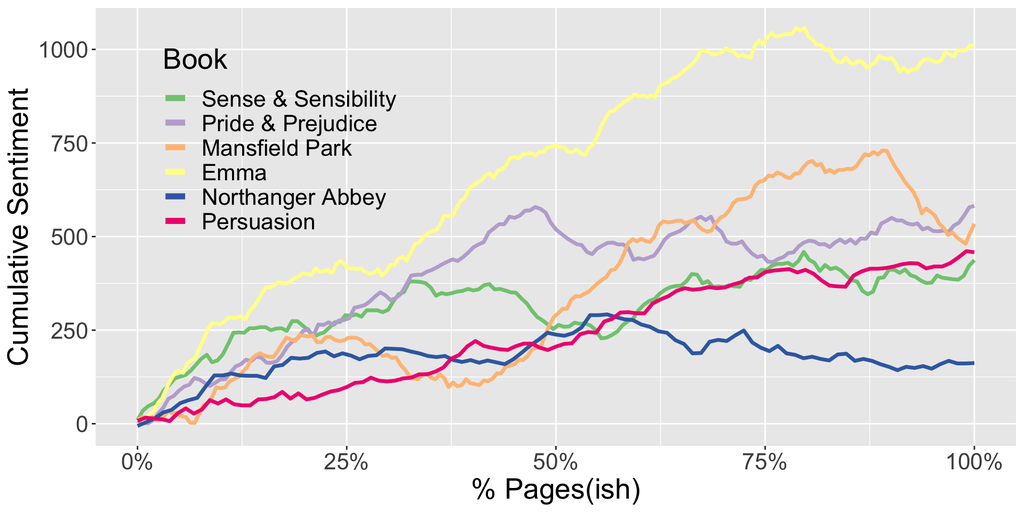

## Plotting Aside: Put Legend **Inside** the Figure

```r
transparent_legend =  theme(
  legend.background = element_rect(fill = "transparent"),
  legend.key = element_rect(fill = "transparent",
                            color = "transparent"))
p +
  transparent_legend +
  scale_color_brewer(type = "qual") +
  scale_x_continuous(labels = scales::percent_format()) +
  theme(legend.position = c(0.2, 0.7), text = element_text(size = 20)) +
  guides(colour = guide_legend(title = "Book",
                               override.aes = list(linewidth = 2)))
```

## Example classification

```r
library(tm);
data("AssociatedPress", package = "topicmodels"); AssociatedPress
```

```
<<DocumentTermMatrix (documents: 2246, terms: 10473)>>
Non-/sparse entries: 302031/23220327
Sparsity           : 99%
Maximal term length: 18
Weighting          : term frequency (tf)
```

```r
class(AssociatedPress)
```

```
[1] "DocumentTermMatrix"    "simple_triplet_matrix"
```

```r
head(tidy(AssociatedPress)) # generics::tidy
```

```
# A tibble: 6 × 3
  document term      count
     <int> <chr>     <dbl>
1        1 adding        1
2        1 adult         2
3        1 ago           1
4        1 alcohol       1
5        1 allegedly     1
6        1 allen         1
```

## Compare frequencies: Jane Austen vs. the AP

```r
comparison = tidy(AssociatedPress) %>%
  count(word = term, name = "AP") %>%
  inner_join(count(tidy_books, word, name = "Austen")) %>%
  mutate(AP = AP / sum(AP),
         Austen = Austen / sum(Austen),
         diff = AP - Austen) %>%
  arrange(desc(abs(diff)))
```

```
Joining with `by = join_by(word)`
```

```r
head(comparison)
```

```
# A tibble: 6 × 4
  word            AP  Austen     diff
  <chr>        <dbl>   <dbl>    <dbl>
1 lady      0.000102 0.00580 -0.00569
2 time      0.00382  0.00948 -0.00566
3 sir       0.000120 0.00572 -0.00560
4 sister    0.000216 0.00516 -0.00494
5 elizabeth 0.000162 0.00487 -0.00471
6 friend    0.000288 0.00421 -0.00392
```

## Bag of words

```r
tidy_freq = tidy_books %>%
  dplyr::ungroup() %>%
  count(book, word, name = "count")
head(tidy_freq)
```

```
# A tibble: 6 × 3
  book                word  count
  <fct>               <chr> <int>
1 Sense & Sensibility 1         2
2 Sense & Sensibility 10        1
3 Sense & Sensibility 11        1
4 Sense & Sensibility 12        1
5 Sense & Sensibility 13        1
6 Sense & Sensibility 14        1
```

## Bag of words

`nonum` removes any words that are all numeric (many ways of doing this):

```r
nonum = tidy_freq %>%
  filter(is.na(as.numeric(word)))
```

```
Warning: There was 1 warning in `filter()`.
ℹ In argument: `is.na(as.numeric(word))`.
Caused by warning:
! NAs introduced by coercion
```

```r
head(nonum)
```

```
# A tibble: 6 × 3
  book                word      count
  <fct>               <chr>     <int>
1 Sense & Sensibility 7000l         1
2 Sense & Sensibility abandoned     1
3 Sense & Sensibility abatement     1
4 Sense & Sensibility abbeyland     1
5 Sense & Sensibility abhor         1
6 Sense & Sensibility abhorred      2
```

## Combine “bags”

```r
tidy_ap = tidy(AssociatedPress) %>%
  rename(book = document,
         word = term,
         count = count)
dat = rbind(tidy_ap, tidy_freq)
head(dat)
```

```
# A tibble: 6 × 3
  book  word      count
  <chr> <chr>     <dbl>
1 1     adding        1
2 1     adult         2
3 1     ago           1
4 1     alcohol       1
5 1     allegedly     1
6 1     allen         1
```

## Term-document matrices

Make a `DocuemntTermMatrix`/reshape the data:

```r
dtm = dat %>% cast_dtm(document = book, term = word, value = count)
inspect(dtm[1:6,1:10])
```

```
<<DocumentTermMatrix (documents: 6, terms: 10)>>
Non-/sparse entries: 15/45
Sparsity           : 75%
Maximal term length: 10
Weighting          : term frequency (tf)
Sample             :
    Terms
Docs adding adult ago alcohol allegedly allen apparently appeared arrested
   1      1     2   1       1         1     1          2        1        1
   2      0     0   0       0         0     0          0        1        0
   3      0     0   1       0         0     0          0        1        0
   4      0     0   3       0         0     0          0        0        0
   5      0     0   0       0         0     0          0        0        0
   6      0     0   2       0         0     0          0        0        0
    Terms
Docs assault
   1       1
   2       0
   3       0
   4       0
   5       0
   6       0
```

```r
dtm = as.matrix(dtm)
dtm = dtm/rowSums(dtm)
```

## Classify

Show the similarity (based on count correlations with first document):

```r
cor1 = cor(dtm[1,], t(dtm))[1,]; print(cor1[1:5]);
```

```
         1          2          3          4          5
1.00000000 0.01817799 0.18085240 0.04745425 0.03157564
```

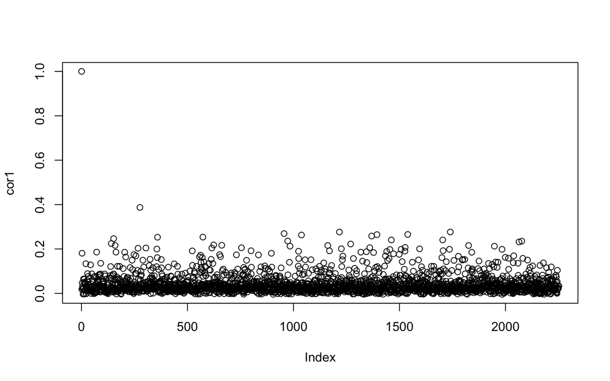

## Classify

We see that there is a large clustering of Austen compared to AP:

```r
cor_ss = cor(dtm["Sense & Sensibility",], t(dtm))[1,]; print(cor_ss[1:5]);
```

```
         1          2          3          4          5
0.02056637 0.03157958 0.02608218 0.05342795 0.04504179
```

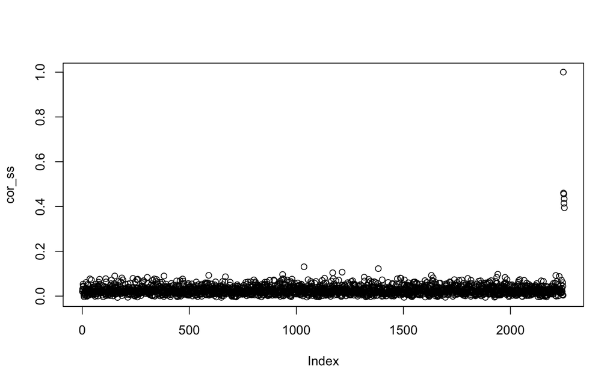

## Classify

The max similarity is not symmetrical (closest document/book to document 1 does not have document 1 as its closest document/book):

```r
(index = which.max(cor1[-1]))
```

```
276
275
```

```r
cor_ss = cor(dtm[index,],t(dtm))[1,]
which.max(cor_ss[-index]) # not 1!
```

```
1126
1125
```

## Stemming

Can use `wordStem` to reduce certain words to their primary stem (e.g. remove gerunds/tense):

```r
library(SnowballC)
wordStem(c("running","fasted"))
```

```
[1] "run"  "fast"
```